# Analysis 2: Human Preferences and Individual Constraints

2026-03-27

## Overview

**Before running this script**, make sure `prepare_data.py` has been run to generate `training_attested.csv`, `human_responses_attested.csv`, and `attested_agg.csv` in `../Data/processed/`.

After the fitting section finishes, run `prepare_results.R` to extract coefficients into CSVs for use in `writeup.qmd`.

**Analysis 2a — Human ordering preference ~ model preference**

For each model × checkpoint, a Bernoulli logistic regression tests whether the model’s preference score for a binomial predicts whether a human participant chose the alphabetical ordering:

$$\text{resp\_binary} \sim \text{preference} + (1 \mid \text{binom}), \quad
\text{family} = \text{Bernoulli}$$

**Analysis 2b — Model preference ~ individual constraints**

For each model × checkpoint, the single `AbsPref` predictor from the main analysis is replaced by all ten individual phonological/semantic constraints simultaneously:

$$\text{preference} \sim (\text{Form} + \text{Percept} + \cdots + \text{BStress})
\times \ln(\text{OverallFreq}) + \text{RelFreq} \times \ln(\text{OverallFreq})
+ (1 \mid \text{binom})$$

**Analysis 2c — Prediction accuracy by overall frequency**

No model fitting required. Accuracy (model preference sign matches human majority sign) is computed from `attested_agg.csv` for each model × checkpoint × frequency quintile.

# Results

## 2c: Prediction accuracy by overall frequency

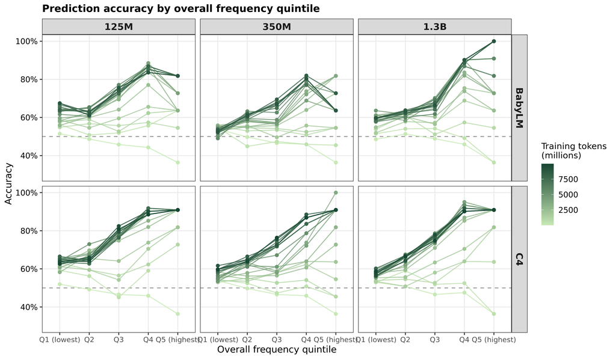

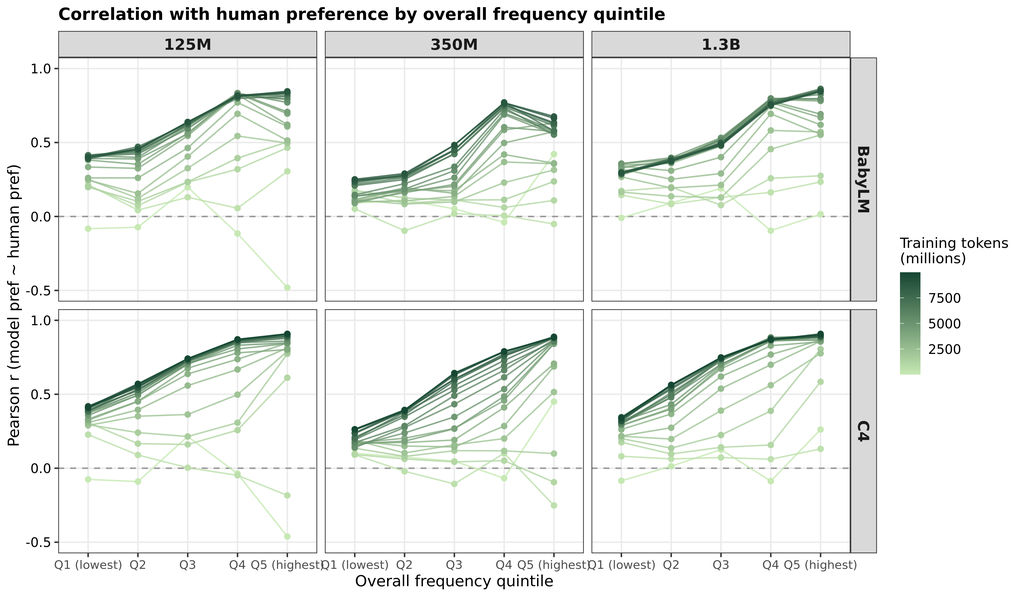

## 2a raw data: correlation between model preference and human preference over training

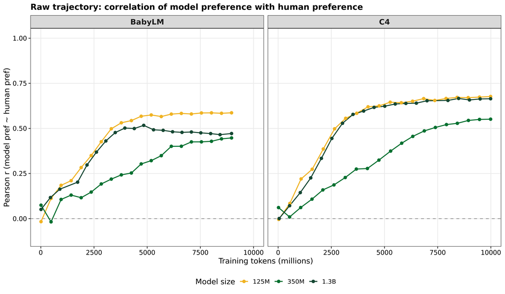

## 2b raw data: correlation between model preference and each constraint over training

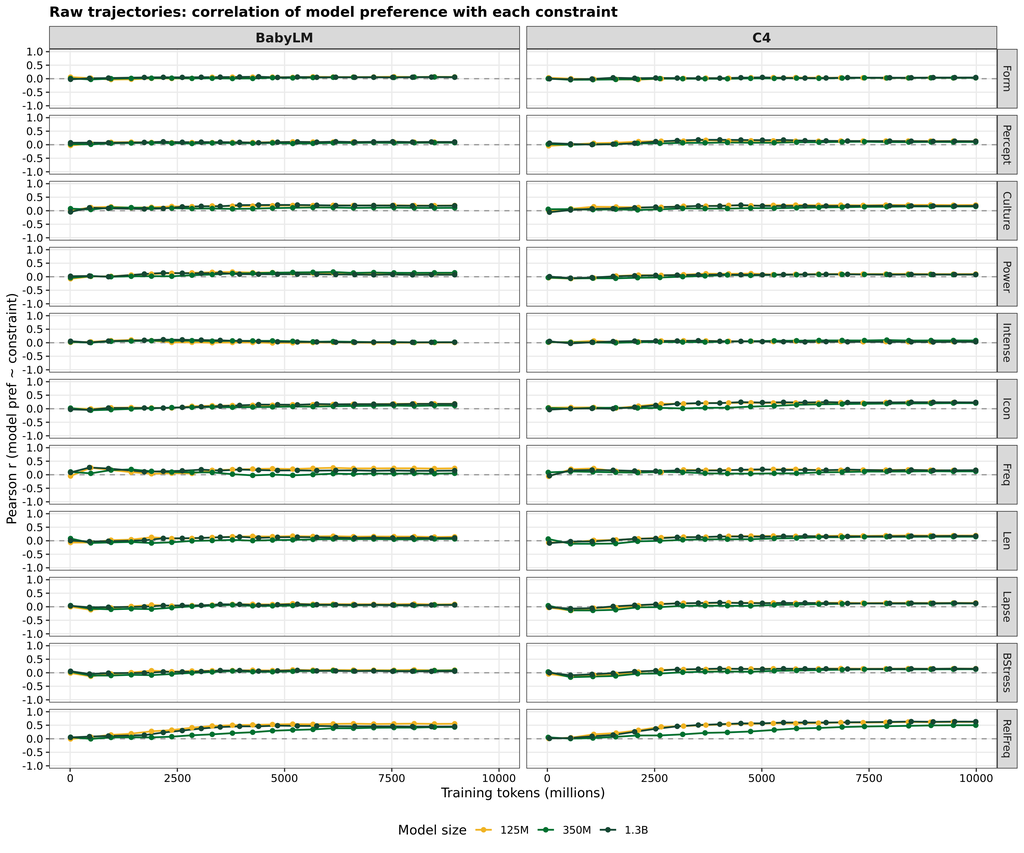

# Fitting

Cells below fit models and save `.rds` files. Already-fitted models are skipped automatically — re-run at any time to fill in missing checkpoints. After fitting, run `prepare_results.R` to extract coefficients into CSVs.

## 2a: `resp_binary ~ preference + (1 | binom)` (Bernoulli)

## 2b: `preference ~ (constraints) * log_total_c + RelFreq * log_total_c + (1 | binom)` (Gaussian)

# Results (brms models)